# Attainment and Attendance in East Sussex

What the national model behind *How to Pull the Right Lever* says about the county’s secondary schools, with comparisons to Brighton and Hove. **Draft for discussion.**

Author

Affiliation

Adam Dennett

Bartlett Centre for Advanced Spatial Analysis, University College London

Published

October 30, 2026

**WarningDraft for discussion**

This is a first draft, prepared for conversation with East Sussex County Council. Every figure is computed from published Department for Education data and from the national models documented in [How to Pull the Right Lever](https://adamdennett.github.io/school_attainment_tool/pulling_the_right_lever_v2.html). Nothing here uses pupil-level records. The interpretation is the author’s and is offered as a starting point, not a conclusion.

# Summary

**East Sussex’s secondary attainment sits below the national average, and the national model can say why.** In 2024-25 the county’s 26 state-funded secondary schools averaged 43.8 in Attainment 8 against 46.9 across England (120th of 152 authorities), and its disadvantaged pupils 33.0 against 37.8 (135th).

- **Three things account for nearly all of the gap: absence, prior attainment and place.** Taking the county’s school-years over 2021/22–2024/25 together, higher absence costs about 1.1 points a pupil and lower Key Stage 2 attainment on entry about 1.0. For disadvantaged pupils the gap is wider, 4.2 points. There, absence costs 1.2 points and being in the South East costs 1.0, once the county’s own small positive effect is netted off.
- **Concentrations of disadvantage are not part of the explanation.** The county’s schools are slightly *less* disadvantaged than the national average, so that term works marginally in its favour.
- **The county’s schools are doing about what the national model expects of them.** East Sussex ranks 49th of 152 authorities once intake and context are accounted for. That is above the middle, but not distinguishable from average. Brighton and Hove is 5th.
- **Absence is high, long-standing and improving.** In autumn and spring 2025/26 the county’s secondary absence was 8.9% against 8.0% in England, the 31st highest of 152 authorities. It was 9th highest before the pandemic. Since 2022/23 it has fallen by 1.3 points, twice as fast as England.
- **Unlike Brighton and Hove’s, East Sussex’s absence is largely what its intake predicts.** The county runs 0.32 points above the absence its pupils’ profile would predict (59th of 151). Brighton and Hove runs 2.0 above (3rd). That does not make East Sussex’s absence unaddressable. It does mean the county’s problem is the national problem, concentrated, rather than a local anomaly.
- **Illness drives most of the excess, then unauthorised absence.** Illness accounts for 0.62 of the 0.88-point gap to England, and unauthorised absence for 0.31. Reduced timetables are used more than nationally.
- **Suspensions are a distinct issue, and a large one.** In 2024/25 the county suspended at 28.0 per 100 secondary pupils against 21.2 in England, more than twice Brighton and Hove’s 13.0. But sessions lost to suspension are about 3% of all absence. Suspensions matter for the pupils concerned. They are not what makes the county’s absence high.
- **The gains from attendance are concentrated.** If the 20 schools above the national average absence rate reached it, the model predicts gains of up to 4.3 Attainment 8 points at the hardest-hit schools, and more for their disadvantaged pupils. Moving every school’s disadvantage to the county average would buy at most 1.0.
- **Hastings is where the problems coincide.** Its three secondary schools have the county’s highest disadvantage and lowest attainment, and two of them sit at the bottom of the county’s value-added table. Both of those moved to a new trust in 2025/26.
- **The districts differ, but because of their schools.** Adding a district level to the national model shows Hastings below expectation and Lewes above it. With each school’s own record in the model as well, no East Sussex district has an effect of its own on attainment or attendance. The differences are a handful of schools at each end.
- **Trusts matter about as much as the local authority, and more for disadvantaged pupils and attendance.** Nationally, schools in the same multi-academy trust share an effect of about 2% on Attainment 8 and 7% on absence. Few individual trusts can be told apart from average, but two of East Sussex’s stand out: United Learning (Seahaven) for attainment, and Ark (Ark Alexandra) for disadvantaged pupils and attendance.

# 1 About this analysis

East Sussex County Council asked what its secondary school system looks like through the lens of [How to Pull the Right Lever](https://adamdennett.github.io/school_attainment_tool/pulling_the_right_lever_v2.html) (the *Lever* report from here on). In particular, it asked what is affecting attainment in the county and what part attendance plays. This document applies the same national models to the county. It adds a small number of analyses the Lever report did not need for Brighton and Hove:

- **A decomposition of the gap to England** (Section 4). This is new here. It splits the difference between the county’s average Attainment 8 and England’s into one piece per factor in the model.
- **Absence by register reason, over ten years** (Section 6), using the DfE’s school-level absence release to 2025/26.
- **Suspensions** (Section 6.5), because the county’s rate is among the highest in England.

**What the models are.** Multilevel models of school-level Attainment 8 for every state-funded mainstream secondary school in England, 2021/22 to 2024/25. They are fitted separately for all pupils, disadvantaged pupils and non-disadvantaged pupils. Each predicts a school’s results from:

- its pupils’ disadvantage, absence, English as an additional language and Key Stage 2 prior attainment;
- its admissions policy and the local authority’s segregation index;
- three teacher workforce measures;
- the school’s Ofsted rating, and the region, local authority and year it sits in.

They explain around 80% of the variation between schools. They are the published models, used as they are. Three sections refit copies of them to ask questions the published versions cannot: Section 5.1 adds a district level, Section 5.2 a multi-academy trust level, and Section 7.1 separates absence from intake.

**What they cannot do.** The models describe schools, not pupils. A school’s absence rate and its results move together across England, and the model measures how strongly. It cannot show that one causes the other for any individual child, and the scenarios below are indications of scale, not forecasts. The Lever report discusses this at length ([Section 4.3](https://adamdennett.github.io/school_attainment_tool/pulling_the_right_lever_v2.html#sec-inference)).

**Years.** The model covers the four complete years 2021/22 to 2024/25. Absence is published a year ahead of results, so the absence sections run to autumn and spring 2025/26. The value-added tables add provisional 2025/26 results, predicted from the same models as the Lever report’s KS4 addendum does.

# 2 The county’s schools

[interactive chart not shown]

East Sussex’s state-funded secondary schools within the county’s five districts and boroughs, coloured by overall absence in 2024/25. Choose another measure from the menu above the map; circle size is the school’s roll. Hover over a school for its figures and who runs it.

East Sussex has 26 state-funded mainstream secondary schools teaching 28,820 pupils. All are non-selective. 18 are academies and 8 are maintained. One is Catholic (St Richard’s in Bexhill) and two are Church of England. The county also has a large independent sector, which is outside these models. The schools fall into two quite different settings:

- the coastal towns of Hastings and St Leonards, Bexhill, Eastbourne, Seaford, Newhaven, Peacehaven and Rye;
- the market towns and villages of the Weald and the Lewes and Rother hinterlands.

Schools by district and borough, 2024/25. Unweighted school means.

| District | Schools | Pupils | FSM % | Absence % | Persistent absence % | KS2 (centred) | Attainment 8 | Attainment 8, disadvantaged |
| --- | --- | --- | --- | --- | --- | --- | --- | --- |
| Hastings | 3 | 3,561 | 35.1 | 10.1 | 32.1 | 3.7 | 37.8 | 29.5 |
| Eastbourne | 6 | 6,374 | 30.0 | 9.4 | 24.6 | 2.7 | 42.7 | 33.2 |
| Rother | 5 | 4,984 | 25.6 | 9.4 | 26.2 | 5.2 | 45.4 | 34.5 |
| Lewes | 6 | 5,756 | 21.5 | 10.2 | 26.5 | 3.2 | 45.4 | 32.2 |
| Wealden | 6 | 8,145 | 20.0 | 9.4 | 25.4 | 4.4 | 45.1 | 34.0 |

Hastings stands apart. Its 3 schools average 35% disadvantaged, 10.1% absence and 37.8 in Attainment 8. The 16 coastal schools together are more disadvantaged than the 10 inland ones (29% against 21%). They also arrive with lower prior attainment and score 3.3 points lower. Absence differs much less between the two (9.6% against 9.8%): some of the county’s highest-absence schools are inland.

## 2.1 Who runs the county’s schools

In 2024/25 the county’s 26 schools were run by 11 different multi-academy trusts, 2 single-academy trusts and the county council:

- **8 maintained schools**, run by the county council.
- **15 schools in multi-academy trusts.** Some are large national trusts: United Learning, Ark, and the University of Brighton Academies Trust. Some are trusts of two or three local schools.
- **2 single-academy trusts.**
- **1 academy whose trust the DfE records no name for that year**: Hailsham Community College, which closed in August 2025.

6 of the academies are *sponsored*. They were placed with a trust, usually because they were judged to be struggling, rather than converting by choice. They are concentrated on the coast: in Hastings, Eastbourne and Newhaven.

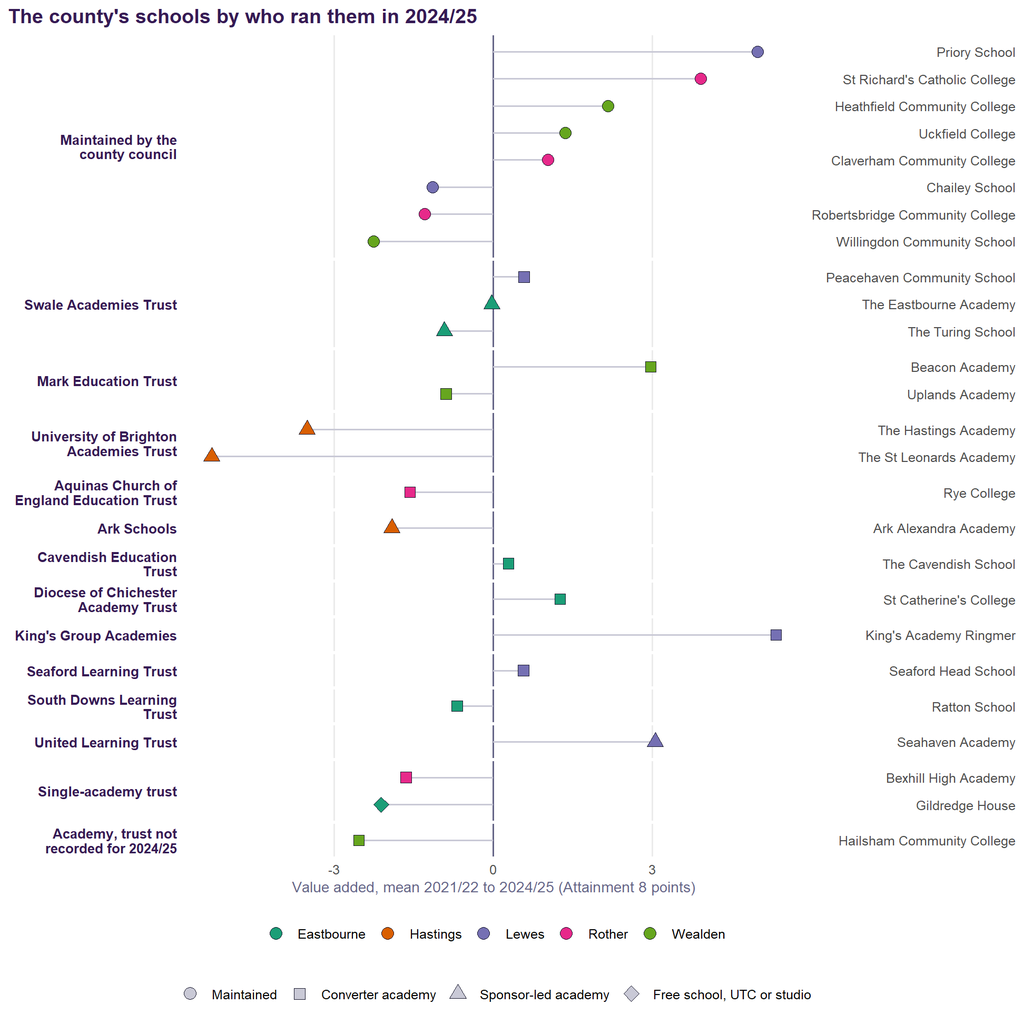

Figure 1: Who ran each school in 2024/25, and how far its results sat above or below the national model’s expectation over 2021/22 to 2024/25 (Attainment 8 points). Each row is a governing body; each dot a school, coloured by district, shaped by how it came to be run that way. Changes since are listed in the table below.

There is no simple pattern by governance:

- **The four strongest schools on value added:** King’s Academy Ringmer (King’s Group Academies); Priory School (maintained); St Richard’s Catholic College (maintained); Seahaven Academy (United Learning Trust).
- **The four weakest:** The St Leonards Academy (University of Brighton Academies Trust); The Hastings Academy (University of Brighton Academies Trust); Hailsham Community College (Academy, trust not recorded for 2024/25); Willingdon Community School (maintained).

Maintained schools and academies, large trusts and small ones, appear at both ends. Section 5.2 asks the question formally.

Table 1: Schools whose governing body has changed since 2024/25, from Get Information about Schools (October 2026).

| School | District | Run by, 2024/25 | Run by now | Now |
| --- | --- | --- | --- | --- |
| Bexhill High Academy | Rother | Single-academy trust | Mulberry Schools Trust | Academy converter |
| Gildredge House | Eastbourne | Single-academy trust | Gildredge House Free School | Free schools |
| Hailsham Community College → Hailsham Academy | Wealden | Academy, trust not recorded for 2024/25 | Mark Education Trust | Academy converter |
| The Hastings Academy → Mulberry Academy Hastings | Hastings | University of Brighton Academies Trust | Mulberry Schools Trust | Academy sponsor led |
| Robertsbridge Community College | Rother | Maintained by the county council | Single-academy trust | NA |
| The St Leonards Academy → Mulberry Academy St Leonards | Hastings | University of Brighton Academies Trust | Mulberry Schools Trust | Academy sponsor led |
| St Richard's Catholic College | Rother | Maintained by the county council | Single-academy trust | NA |

Every state-funded secondary school, 2024/25. KS2 is the cohort’s mean Key Stage 2 score, centred as in the national model (England’s school average is about 4.5).

| School | District | Type | Pupils | FSM % | Absence % | Persistent % | KS2 | EHCP % | Att 8 | Att 8 disadv. | Ofsted |
| --- | --- | --- | --- | --- | --- | --- | --- | --- | --- | --- | --- |
| Gildredge House | Eastbourne | Academy | 1168 | 22.3 | 6.3 | 15.0 | 4.1 | 1.6 | 46.6 | 35.1 | Good |
| Ratton School | Eastbourne | Academy | 1197 | 23.3 | 9.1 | 23.7 | 2.4 | 1.1 | 42.9 | 29.8 | Good |
| St Catherine's College | Eastbourne | Academy | 1072 | 21.9 | 8.7 | 24.9 | 4.8 | 1.3 | 47.4 | 38.4 | Good |
| The Cavendish School | Eastbourne | Academy | 1372 | 25.9 | 6.4 | 13.4 | 4.1 | 1.7 | 47.2 | 41.3 | Good |
| The Eastbourne Academy | Eastbourne | Academy | 800 | 41.9 | 10.8 | 29.2 | -0.1 | 2.0 | 37.7 | 32.3 | Requires Improvement |
| The Turing School | Eastbourne | Academy | 765 | 44.8 | 15.0 | 41.7 | 0.7 | 1.2 | 34.5 | 22.1 | Requires Improvement |
| Ark Alexandra Academy | Hastings | Academy | 1431 | 32.1 | 8.9 | 27.9 | 4.1 | 0.6 | 42.4 | 34.3 | Requires Improvement |
| The Hastings Academy | Hastings | Academy | 808 | 33.8 | 10.2 | 32.9 | 4.4 | 2.3 | 38.0 | 28.4 | Requires Improvement |
| The St Leonards Academy | Hastings | Academy | 1322 | 39.3 | 11.1 | 35.5 | 2.7 | 2.8 | 33.1 | 25.7 | Requires Improvement |
| Chailey School | Lewes | Maintained | 855 | 10.7 | 6.8 | 18.1 | 5.6 | 2.7 | 49.2 | 36.2 | Good |
| King's Academy Ringmer | Lewes | Academy | 642 | 24.2 | 10.0 | 27.6 | 2.7 | 2.8 | 47.5 | 32.1 | Good |
| Peacehaven Community School | Lewes | Academy | 903 | 28.7 | 11.2 | 25.9 | -0.1 | 5.2 | 39.7 | 28.8 | Good |
| Priory School | Lewes | Maintained | 1163 | 20.9 | 12.1 | 32.9 | 5.3 | 3.8 | 46.3 | 25.5 | Good |
| Seaford Head School | Lewes | Academy | 1448 | 14.2 | 8.6 | 22.6 | 3.9 | 1.8 | 49.4 | 38.4 | Outstanding |
| Seahaven Academy | Lewes | Academy | 745 | 30.2 | 12.6 | 31.7 | 1.7 | 1.3 | 40.2 | 32.4 | Good |
| Bexhill High Academy | Rother | Academy | 1454 | 33.0 | 8.9 | 23.2 | 4.7 | 2.5 | 41.6 | 32.6 | Requires Improvement |
| Claverham Community College | Rother | Maintained | 1148 | 21.6 | 7.2 | 18.7 | 4.8 | 1.2 | 50.2 | 40.9 | Good |
| Robertsbridge Community College | Rother | Maintained | 733 | 26.0 | 12.3 | 34.9 | 6.6 | 4.8 | 40.2 | 29.4 | Inadequate |
| Rye College | Rother | Academy | 616 | 31.1 | 12.9 | 42.5 | 3.7 | 1.0 | 36.7 | 26.1 | Good |
| St Richard's Catholic College | Rother | Maintained | 1033 | 16.3 | 5.7 | 11.8 | 6.1 | 1.8 | 58.4 | 43.4 | Good |
| Beacon Academy | Wealden | Academy | 1662 | 15.5 | 9.1 | 23.8 | 4.7 | 1.9 | 50.2 | 40.2 | Outstanding |
| Hailsham Community College | Wealden | Academy | 1615 | 25.5 | 10.0 | 28.9 | 2.8 | 2.1 | 35.4 | 27.8 | Inadequate |
| Heathfield Community College | Wealden | Maintained | 1437 | 17.7 | 10.5 | 28.9 | 4.7 | 2.8 | 50.5 | 47.0 | Good |
| Uckfield College | Wealden | Maintained | 1602 | 13.9 | 10.6 | 26.6 | 4.8 | 1.7 | 46.9 | 23.8 | Outstanding |
| Uplands Academy | Wealden | Academy | 736 | 29.4 | 9.0 | 24.8 | 4.6 | 2.3 | 42.5 | 36.6 | Good |
| Willingdon Community School | Wealden | Maintained | 1093 | 18.2 | 7.4 | 19.1 | 4.8 | 3.3 | 45.0 | 28.5 | Good |

# 3 How East Sussex compares

East Sussex, Brighton and Hove and England, 2024/25. Means of school-level figures, as in the Lever report; ranks are among all local authorities (1 = highest).

| Measure | East Sussex | Brighton and Hove | England |
| --- | --- | --- | --- |
| Attainment 8, all pupils | 43.8 (120th) | 45.5 (85th) | 46.8 |
| Attainment 8, disadvantaged | 33.0 (135th) | 33.9 (122nd) | 37.7 |
| Attainment 8, non-disadvantaged | 47.5 (118th) | 49.6 (68th) | 49.9 |
| Disadvantage gap (points) | 14.5 (29th) | 15.7 (13th) | 12.2 |
| Disadvantaged (FSM6) % | 25.5 (89th) | 28.8 (74th) | 28.4 |
| Overall absence % | 9.7 (27th) | 11.3 (1st) | 8.6 |
| Persistent absence % | 26.4 (31st) | 30.6 (4th) | 23.9 |
| Mean KS2 (centred) | 3.79 (112th) | 4.71 (50th) | 4.47 |
| EAL % | 6.3 (130th) | 13.0 (83rd) | 18.4 |
| EHC plan % | 2.2 (128th) | 4.1 (12th) | 2.9 |

Three features stand out against England:

- **Lower attainment for every group.** The shortfall is widest for disadvantaged pupils, so the county’s disadvantage gap is among the widest fifth in England.
- **Lower prior attainment.** Pupils arrive from primary school with lower Key Stage 2 scores than the national average. The national model treats this as one of the two strongest predictors of results at 16.
- **Higher absence, but not higher disadvantage.** The county’s schools are less disadvantaged than the national average and less than Brighton and Hove’s. Its absence is high.

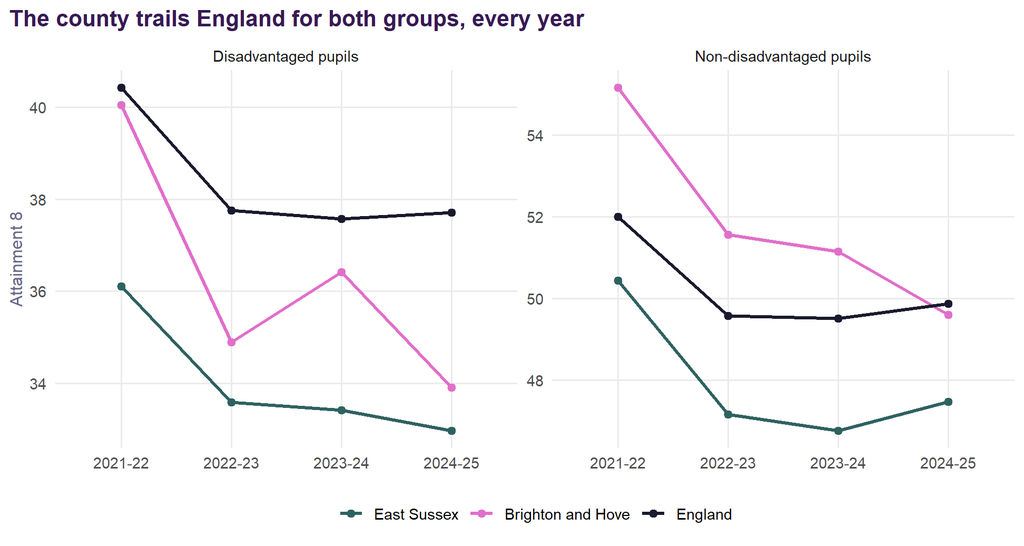

Attainment 8 for disadvantaged and non-disadvantaged pupils, school means, 2021/22 to 2024/25. England is the mean over all schools.

# 4 What explains attainment in East Sussex

The national model predicts a school’s Attainment 8 from its intake and circumstances. Averaged over a local authority’s schools, those predictions add up exactly to the authority’s average result, piece by piece. That makes it possible to ask how much of the gap between East Sussex and England each factor accounts for:

- the county’s absence against England’s;
- its prior attainment against England’s;
- and so on through every other term.

The pieces add up to the whole gap. Anything the model’s factors do not cover lands in the last bar, labelled “unexplained”, and for East Sussex it is small.

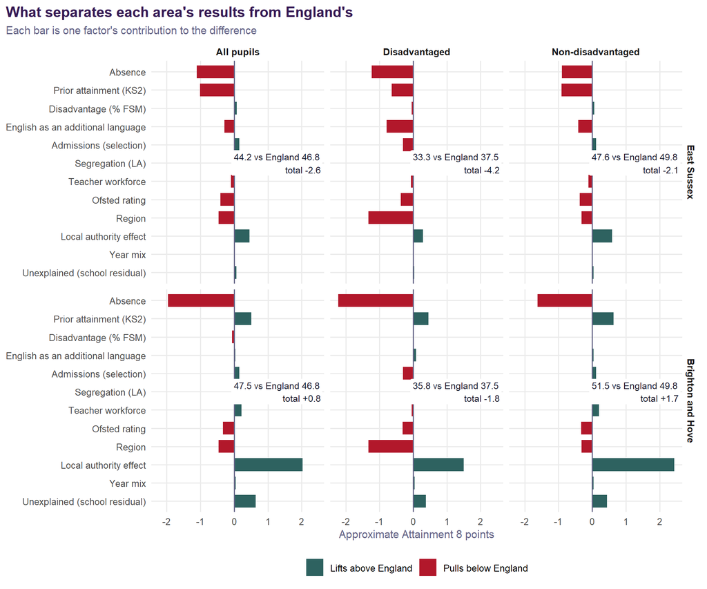

Figure 2: Why average Attainment 8 differs from England’s, by factor, all school-years 2021/22 to 2024/25. Bars to the left pull the area below England; bars to the right lift it. The pieces sum to the total gap printed in each panel. Approximate Attainment 8 points.

The same decomposition for East Sussex, in Attainment 8 points. Region and local authority are shown together as ‘place’.

| Factor | All pupils | Disadvantaged | Non-disadvantaged |
| --- | --- | --- | --- |
| Absence | -1.11 | -1.23 | -0.90 |
| Prior attainment (KS2) | -1.02 | -0.64 | -0.91 |
| Ofsted rating | -0.41 | -0.37 | -0.36 |
| English as an additional language | -0.29 | -0.78 | -0.41 |
| Teacher workforce | -0.09 | -0.06 | -0.11 |
| Place (region and local authority) | -0.00 | -1.03 | +0.28 |
| Unexplained (school residual) | +0.06 | +0.03 | +0.04 |
| Disadvantage (% FSM) | +0.08 | -0.05 | +0.07 |
| Other model terms | +0.14 | -0.31 | +0.11 |

**For all pupils**, East Sussex is 2.6 points below England. Almost all of that is two factors of roughly equal size:

- **absence** (-1.11);
- **prior attainment** (-1.02).

Lower Ofsted ratings and a low share of pupils with English as an additional language take a little more. Place nets out at about zero: the South East’s negative regional effect is offset by the county’s own small positive one.

**For disadvantaged pupils** the gap is 4.2 points, and the picture changes in two ways:

- **Place matters much more.** Of England’s nine regions, the South East has the most negative regional effect for disadvantaged pupils: they do less well there than pupils with the same intake, attendance and prior attainment elsewhere. Place takes 1.03 points, nearly as much as absence (1.23).
- **English as an additional language takes more.** East Sussex’s disadvantaged pupils are rarely from the multilingual families whose children do well nationally (0.78).

Neither is something the county can change. Absence and prior attainment are the two pieces it can.

**What does not appear** is just as informative. Concentrations of disadvantage contribute almost nothing, and if anything work in the county’s favour, because its schools are less disadvantaged than England’s. The segregation index contributes nothing. Teacher workforce measures contribute little. Nothing here suggests that the mix of pupils between schools is what holds East Sussex back.

**The contrast with Brighton and Hove is the clearest thing in the chart.** Absence costs Brighton and Hove *more* than it costs East Sussex (1.96 points against 1.11), and its pupils arrive with *higher* prior attainment. What lifts the city above England is its local authority effect: its schools get more out of their pupils than the model predicts (+2.03 points). East Sussex has neither the city’s prior-attainment advantage nor its school effect. That leaves absence as the largest single addressable factor.

# 5 The county’s own effect

Once intake and circumstances are accounted for, each local authority’s schools sit somewhere above or below the national expectation. This is the local authority random effect in the model, plotted for every authority in Figure 3.

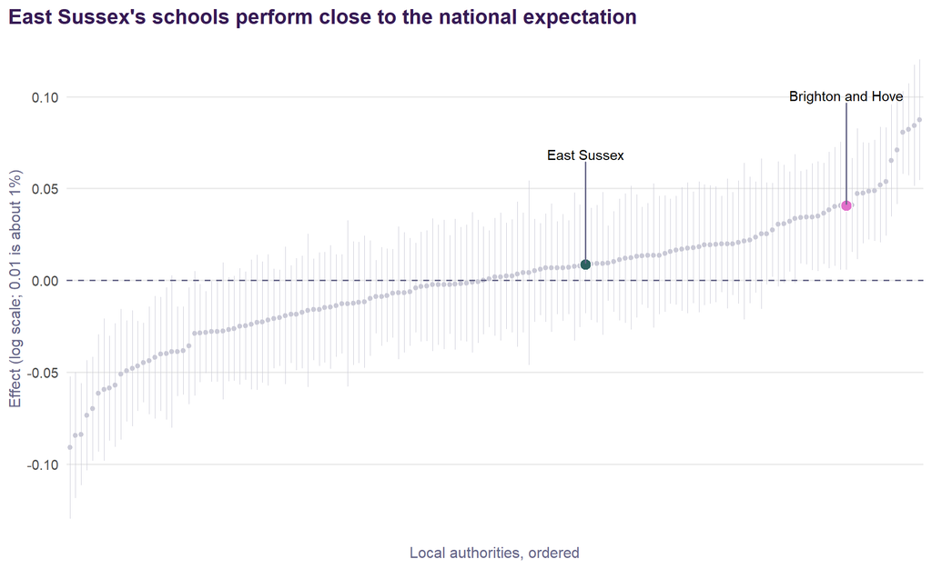

Figure 3: Local authority effects from the published national models, disadvantaged pupils. Each dot is an authority, ordered by estimate, with a 95% interval. East Sussex is teal; Brighton and Hove pink.

Table 2: Local authority effects and ranks (1 = best). ‘Significant’ means the 95% interval excludes zero.

| Group | Local authority | Effect (%) | Rank | Significant |
| --- | --- | --- | --- | --- |
| All pupils | Brighton and Hove | +4.5 | 5th of 152 | Yes |
| All pupils | East Sussex | +1.1 | 49th of 152 | No |
| Disadvantaged | Brighton and Hove | +4.2 | 14th of 151 | Yes |
| Disadvantaged | East Sussex | +0.9 | 60th of 151 | No |
| Non-disadvantaged | Brighton and Hove | +5.0 | 4th of 151 | Yes |
| Non-disadvantaged | East Sussex | +1.2 | 50th of 151 | No |

East Sussex ranks 49th for all pupils, 60th for disadvantaged pupils and 50th for non-disadvantaged pupils. In each case it is slightly above the middle, worth about 1.1% on Attainment 8, and in none is it distinguishable from average. **The county’s schools, taken together, get about the results the national model expects for pupils like theirs, in a place like theirs.**

**Does that depend on controlling for absence?** For Brighton and Hove it depends on it entirely, and this was one of the central findings of the Lever report:

- with the absence control, the city ranks 15th for disadvantaged pupils;
- without it, 69th.

The city’s schools are effective for the pupils who attend, and the city’s absence erases the advantage. For East Sussex the control makes almost no difference: 57th with it, 61st without.[^1] The county’s absence is not hiding unusually effective schools. It is at about the level its intake predicts (Section 6.2), so taking it out of the model moves the county very little.

## 5.1 Do the districts differ?

The published models place schools in local authorities within regions. In a two-tier county that skips a level. East Sussex is five districts and boroughs with very different towns in them, and it is fair to ask whether those districts carry an effect of their own.

**The test.** To find out, a district level is added to the published model, nested inside the local authority, and the model is refitted with and without it on identical school-years. This is done for all three attainment outcomes and for the first-stage absence model. Every school in England was placed in its district from its postcode. In a unitary authority the district is the authority, so the district variance is estimated from the two-tier counties: 177 districts in all.

**The catch.** The published models have no term for the individual school. A school that does persistently well or badly across its four years therefore has nowhere to go but the lowest place level in the model. When a district has only three schools, as Hastings does, a “district effect” is largely those three schools. So the test is run twice: once on the published specification, and once with a school term added, which asks whether the district matters *beyond* the schools in it.

Table 3: Does adding a district level improve the model? Likelihood-ratio tests (the p-value is halved because a variance cannot be negative), with the district standard deviation alongside the local authority’s. A standard deviation of 0.02 is about 2% of Attainment 8, or of the absence rate.

| Specification | Outcome | LR statistic | p | BIC prefers | District SD | LA SD |
| --- | --- | --- | --- | --- | --- | --- |
| Published specification | All pupils | 195.0 | < 0.001 | District | 0.027 | 0.015 |
| Published specification | Disadvantaged | 82.6 | < 0.001 | District | 0.029 | 0.025 |
| Published specification | Non-disadvantaged | 264.3 | < 0.001 | District | 0.025 | 0.016 |
| Published specification | Absence (stage 1) | 128.4 | < 0.001 | District | 0.054 | 0.045 |
| With a school term | All pupils | 13.2 | < 0.001 | District | 0.019 | 0.016 |
| With a school term | Disadvantaged | 4.3 | 0.019 | No district | 0.017 | 0.029 |
| With a school term | Non-disadvantaged | 41.0 | < 0.001 | District | 0.022 | 0.017 |
| With a school term | Absence (stage 1) | 3.2 | 0.038 | No district | 0.032 | 0.040 |

**Nationally, districts matter, but much less once schools are counted.** On the published specification the district level is overwhelmingly significant for every outcome. Districts within a county differ by more than counties do from each other: the district standard deviation is 0.027 for all pupils, against 0.015 for the local authority.

With a school term most of that goes. A district effect survives for all pupils and, more clearly, for non-disadvantaged pupils. For disadvantaged pupils and for absence it is marginal (p = 0.02 and 0.04), and the BIC prefers the model without it. Of the 177 county districts, 2 have an individually significant effect on attainment once schools are counted, and 0 on absence.

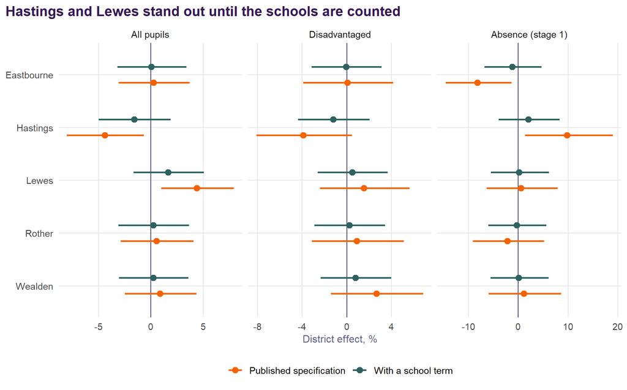

Figure 4: East Sussex’s five districts: the district effect on Attainment 8 (all pupils and disadvantaged) and on absence, with 95% intervals, before and after adding a school term. Effects are percentages of the outcome over and above the county’s own effect. For absence, positive means more absence than intake predicts.

**In East Sussex the districts’ differences are their schools.** On the published specification two districts stand out. Hastings sits 4.4% below expectation for all pupils and runs 9.9% more absence than its intake predicts. Lewes sits 4.4% above. Eastbourne runs 8.2% *less* absence than predicted.

A plain comparison of the county’s 26 schools says the same: value added differs by district (F = 3.7, p = 0.02). That comparison runs from Hastings at -3.6 points a pupil to Lewes at +2.2.

With a school term, every one of those district effects is indistinguishable from zero. Hastings’ attainment effect falls to -1.6% and its absence effect to +2.0%. What looked like Hastings was two of its three schools:

- **The St Leonards Academy**: -12.3% on attainment and +31% on absence, beyond its intake;
- **The Hastings Academy**: -7.5% and +35%;
- **Ark Alexandra Academy**, the third school in the same town, is much closer to expectation: -2.7% and +5%.

Lewes’ advantage is likewise King’s Academy Ringmer, Priory School and Seahaven Academy, not the district’s other three schools.

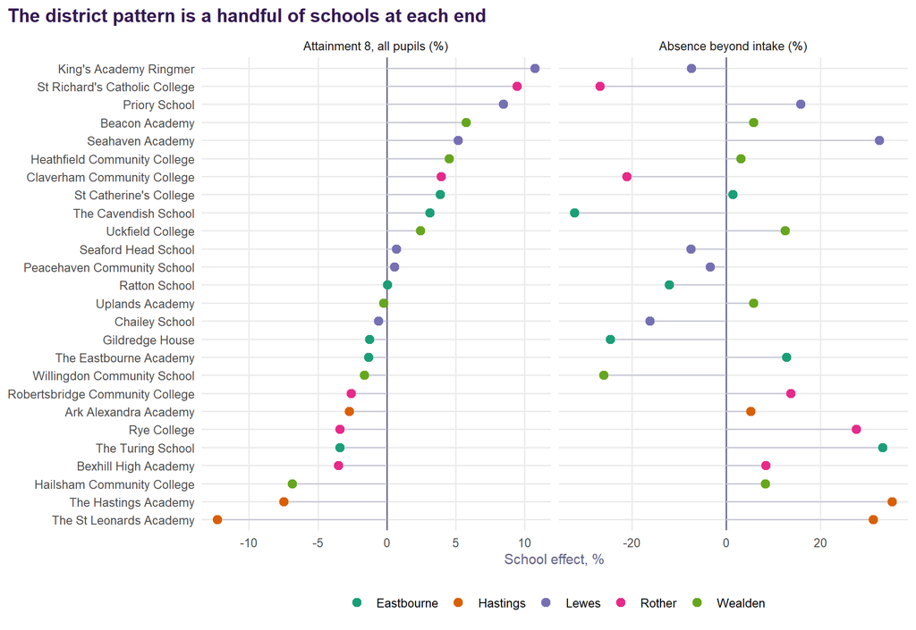

Figure 5: Each East Sussex school’s own persistent effect from the model with a school term, coloured by district: Attainment 8 (all pupils) and absence beyond what its intake predicts. Schools are in the same order in both panels, by their attainment effect.

**What this means for the county.**

- **District is a useful way to describe where the difficulties are.** Hastings has the county’s most disadvantaged intakes and two of the county’s three lowest-performing schools.
- **It is not, on this evidence, a separate cause.** The model finds no sign that being in Hastings, Eastbourne or Lewes affects a school’s results or attendance beyond what its intake and its own record explain. A district-wide intervention would be aimed at an effect the data cannot find, where school-level support would be aimed at one it can.
- **The limit of the test.** With three to six schools per district, four years of data cannot fully separate a shared place effect from several schools that happen to sit together. The two Hastings academies have also moved to the same trust together, so what they share is governance as well as geography. A place effect smaller than the school differences could exist and go undetected.

## 5.2 Do trusts make a difference?

Many of the county’s schools are in multi-academy trusts, so it is natural to ask whether a trust carries an effect of its own, like a district might. Do schools in the same trust do better or worse together than their pupils and places would predict?

**How it is tested.** The trust is added to the national model as another grouping level, crossed with the local authority, since many trusts span several. Three choices make the test fair to trusts:

- **The trust that actually ran the school that year.** Membership comes from the DfE’s school-level exclusions file, which names each school’s trust year by year. A school’s results before it joined a trust are never credited to that trust.
- **Each school’s own record is in the model too**, so a trust is not credited or blamed for the persistent strengths of one school.
- **How each school came to be run enters as a fixed effect.** Its route is maintained, converter academy, sponsored academy or free school. This is the point about selection. Sponsored academies were usually placed with a trust *because* they were struggling, so a trust that takes on such schools would look worse for reasons that are not its doing. Comparing like with like on route removes the crudest version of that bias.

The trust term applies only to school-years in a multi-academy trust. Maintained schools and single-academy trusts carry none.

Table 4: Does adding the trust improve the national model? Likelihood-ratio test (p-value halved for the boundary), with the standard deviations of the trust, local authority and school effects. 0.02 is about 2% of Attainment 8, or of the absence rate.

| Outcome | LR statistic | p | BIC prefers | Trust SD | LA SD | School SD |
| --- | --- | --- | --- | --- | --- | --- |
| All pupils | 67 | < 0.001 | Trust | 0.022 | 0.022 | 0.072 |
| Disadvantaged | 136 | < 0.001 | Trust | 0.037 | 0.033 | 0.064 |
| Non-disadvantaged | 207 | < 0.001 | Trust | 0.027 | 0.024 | 0.051 |
| Absence (stage 1) | 121 | < 0.001 | Trust | 0.067 | 0.046 | 0.169 |

**Schools in the same trust do share something.** The trust level is strongly significant for every outcome, and the model is better with it on every criterion. Its size is the useful number:

- **All pupils.** A trust moves Attainment 8 by about 2.2% either way, the same as the local authority does (2.2%). The individual school moves it by 7.2%, about three times as much.
- **Disadvantaged pupils.** The trust matters more, 3.7% against 3.3% for the local authority.
- **Absence.** The trust matters most: 6.7% of the absence rate, beyond intake, against 4.6% for the local authority.

**But few individual trusts can be told apart from average.** Of 701 trusts in England:

- **All pupils:** 7 are significantly above average and 0 below.
- **Disadvantaged pupils:** 12 above and 2 below.
- **Absence:** 6 run significantly more absence than their schools’ intakes predict, and 5 less.

Most trusts are small, and a trust of two or three schools cannot be separated from the schools themselves.

Table 5: How a school came to be run, compared with maintained schools of the same intake, place and Ofsted rating: percentage difference in Attainment 8, and in absence beyond what the intake predicts.

| Route | All pupils | Disadvantaged | Absence (stage 1) |
| --- | --- | --- | --- |
| Converter academy | +1.0% (t = 2.3) | +0.3% (t = 0.7) | -0.9% (t = -1.0) |
| Sponsor-led academy | -1.1% (t = -2.3) | +0.3% (t = 0.7) | +7.1% (t = 6.3) |
| Free school, UTC or studio | -2.0% (t = -3.2) | +0.8% (t = 1.1) | +0.9% (t = 0.6) |

The route shows the selection problem directly. Compared with maintained schools with the same intake, sponsored academies have +7.1% more absence than predicted and -1.1% lower attainment. These schools were sponsored because they were in difficulty. Their histories cannot be separated from what their trusts have done since. The data do not say that sponsorship causes absence. They say that the schools trusts are given are harder, in ways the intake measures do not fully capture.

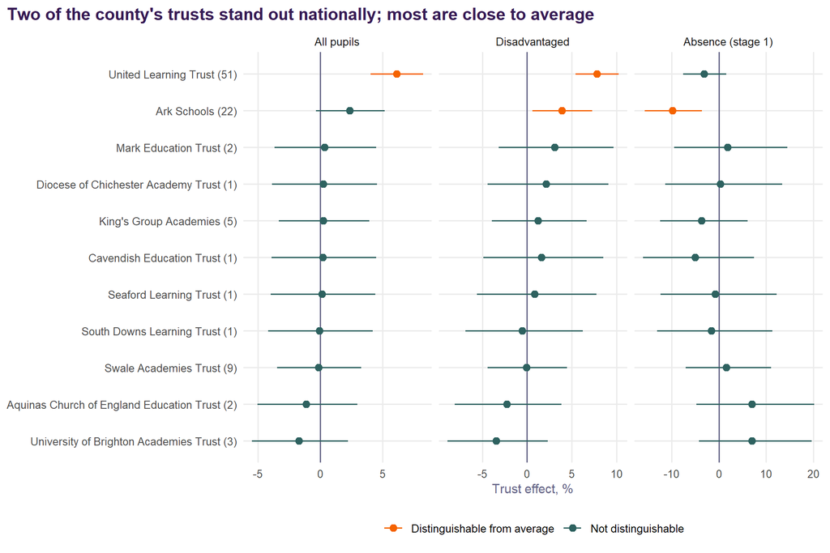

Figure 6: The national effect of each trust that ran an East Sussex school in 2024/25, with 95% intervals: Attainment 8 for all pupils and for disadvantaged pupils, and absence beyond intake (positive means more absence). Each trust’s effect is estimated across all its secondary schools in England, not only its East Sussex ones; the number in brackets is how many it has in the data.

The trusts that ran East Sussex schools in 2024/25 span the range, and two stand out nationally.

- **United Learning**, which runs Seahaven Academy, is among the strongest trusts in England. Across its 51 secondary schools in the data, results are +6.1% above what their intakes predict, and +7.8% for disadvantaged pupils. Seahaven’s own record matches this (Figure 1).
- **Ark Schools**, which runs Ark Alexandra Academy in Hastings, is significantly better than average for disadvantaged pupils (+3.9%). Its schools run 9.8% *less* absence than their intakes predict, among the strongest attendance records of any trust.
- **The University of Brighton Academies Trust** ran The Hastings and St Leonards academies until 2025/26. Its national effect is -1.7% on attainment and +7.0% on absence, neither distinguishable from average. With so few schools in the data, it cannot be separated from the two Hastings schools themselves (Section 5.1).
- **The county’s small local trusts** (Seaford, South Downs, Cavendish and Mark) sit at about zero. With one or two schools each, that is what the model must report. Their trust and their school are the same thing, and the school’s own effect carries the difference.

**What this means for the county.** Trusts are a real level in the system, about as consequential as the local authority itself. They matter more for disadvantaged pupils and attendance than for results overall. Ark’s attendance record and United Learning’s attainment are national strengths with a school in the county, and both are worth learning from. But for most trusts the evidence cannot say whether they are better or worse than average. It cannot say whether the county’s academies would do better under the council, or the council’s schools under a trust. The strongest effect in the model remains the individual school.

# 6 Absence in East Sussex

## 6.1 Ten years of secondary absence

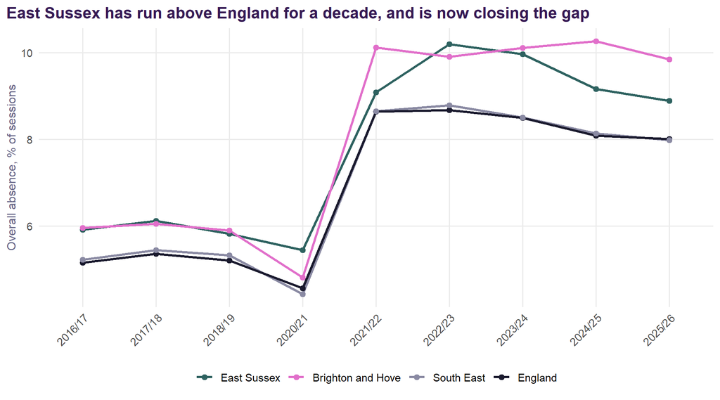

Figure 7: Overall absence in state-funded secondary schools, autumn and spring terms, 2016/17 to 2025/26. Sessions-weighted. 2019/20 was not collected.

Table 6: Secondary absence and persistent absence (10% or more of sessions missed), autumn and spring terms, with rank among local authorities (1 = highest absence).

| Year | Brighton and Hove | East Sussex: absence / persistent | England |
| --- | --- | --- | --- |
| 2016/17 | 6.0% (8th) / 15.0% (18th) | 5.9% (9th) / 15.4% (13th) | 5.2% / 12.8% |
| 2017/18 | 6.1% (11th) / 15.2% (30th) | 6.1% (9th) / 15.8% (21st) | 5.4% / 13.6% |
| 2018/19 | 5.9% (14th) / 13.7% (41st) | 5.8% (18th) / 14.2% (27th) | 5.2% / 12.7% |
| 2020/21 | 4.8% (49th) / 12.0% (65th) | 5.4% (23rd) / 15.0% (20th) | 4.6% / 11.7% |
| 2021/22 | 10.1% (10th) / 31.3% (20th) | 9.1% (54th) / 26.5% (81st) | 8.6% / 26.7% |
| 2022/23 | 9.9% (19th) / 28.7% (20th) | 10.2% (13th) / 29.2% (15th) | 8.7% / 25.2% |
| 2023/24 | 10.1% (13th) / 28.2% (17th) | 10.0% (19th) / 28.7% (12th) | 8.5% / 23.9% |
| 2024/25 | 10.3% (3rd) / 27.2% (8th) | 9.2% (22nd) / 24.9% (22nd) | 8.1% / 21.9% |
| 2025/26 | 9.8% (6th) / 25.5% (17th) | 8.9% (31st) / 23.6% (38th) | 8.0% / 21.6% |

Absence in East Sussex was high long before the pandemic. In 2016/17 and 2017/18 the county was the 9th highest of over 150 authorities, alongside Brighton and Hove. Like everywhere, absence roughly doubled after the pandemic. The county peaked at 10.2% in 2022/23 (13th highest), and has improved every year since, to 8.9% in 2025/26 (31st). Over the same years England fell by 0.7 points and Brighton and Hove by 0.1. East Sussex’s improvement is real and faster than average, but the county is still 0.9 points above England.

## 6.2 Is it the intake?

Absence is partly a property of the pupils a school serves. Lower prior attainment, disadvantage and a lack of English as an additional language all predict higher absence across England. The first stage of the Lever report’s absence decomposition fits that relationship nationally, using intake and region but not the local authority. It then asks how far each authority’s absence is above or below what its intake predicts.

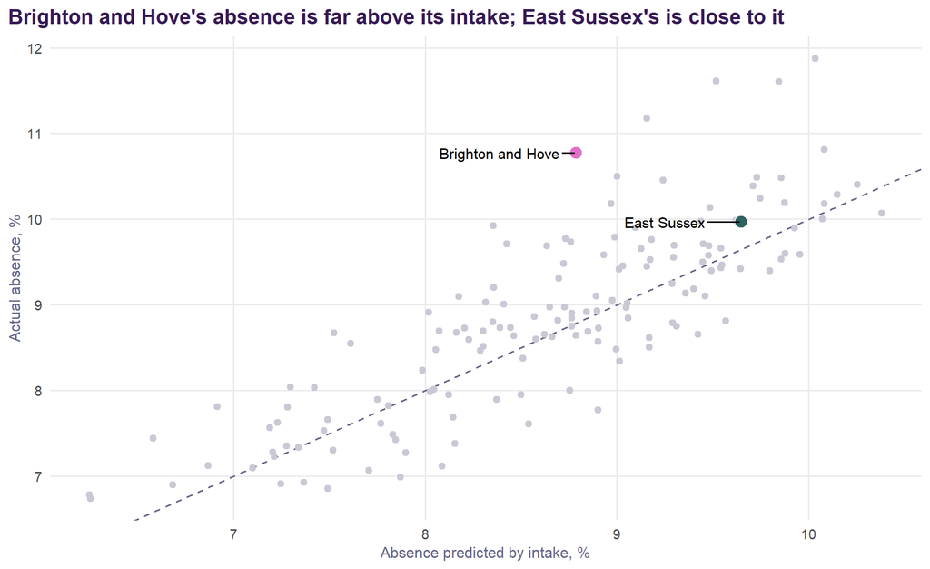

Figure 8: Each local authority’s mean school absence (2021/22 to 2024/25) against the absence its intake predicts. Authorities above the line have more absence than their intake explains.

East Sussex’s intake predicts high absence: 9.6%, against 8.8% for Brighton and Hove’s. Actual absence is 10.0%, only 0.32 points above that (59th of 151). Brighton and Hove’s intake predicts low absence, and its actual absence is 2.0 points above that, the 3rd largest excess in England.

This is the sharpest difference between the two authorities.

- **Brighton and Hove’s absence is a local anomaly.** It has the absence of a much more deprived place without the deprivation. That points to local causes, which is why the Lever report recommended a dedicated study.
- **East Sussex’s absence is the national pattern, at the level its intake produces everywhere.** It has the pupils who are absent most across England: lower prior attainment, little English as an additional language, and coastal deprivation.

That is not a reason for fatalism. “Predicted by intake” means “typical of schools with intakes like this”, and typical is still a lot of absence. Schools with similar intakes vary widely (Section 7.1). The county’s improvement since 2022/23 shows the rate can move. But the levers are likely to be the ones that work nationally for these pupils, rather than a search for something unusual about East Sussex.

## 6.3 What the absence is

Every absent session is recorded against a reason. Figure 9 compares East Sussex’s profile with England’s and Brighton and Hove’s, as a share of all possible sessions.

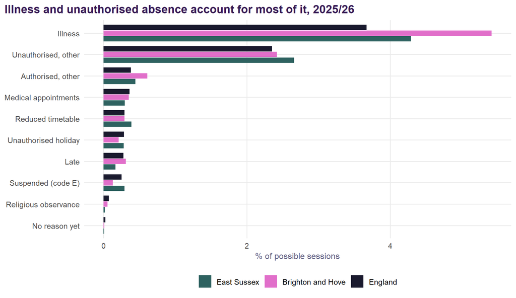

Figure 9: Absence by register reason, autumn and spring terms, state-funded secondary schools, percentage of possible sessions. The ten largest reasons nationally.

Table 7: Where East Sussex’s excess over England comes from, by reason, in percentage points of possible sessions. The rows sum to the total gap.

| Reason | East Sussex | England | Gap | Share of gap |
| --- | --- | --- | --- | --- |
| Illness | 4.29 | 3.67 | +0.62 | 70% |
| Unauthorised, other | 2.66 | 2.35 | +0.31 | 35% |
| Late | 0.17 | 0.28 | -0.11 | -13% |
| Reduced timetable | 0.39 | 0.29 | +0.10 | 11% |
| Medical appointments | 0.30 | 0.36 | -0.07 | -8% |
| Authorised, other | 0.45 | 0.38 | +0.06 | 7% |
| Religious observance | 0.02 | 0.08 | -0.06 | -6% |
| Suspended (code E) | 0.29 | 0.25 | +0.04 | 5% |
| No reason yet | 0.01 | 0.03 | -0.02 | -2% |

East Sussex is 0.88 points above England in 2025/26, and three reasons make up the excess:

- **Illness**, 0.62 points: about 70% of the gap.
- **Unauthorised absence**, 0.31 points. This is the category that covers truancy and absence the school does not accept.
- **Reduced timetables**, 0.10 points. These are pupils formally attending part-time, often while a placement or support is arranged. The figure is small but notable, because it reflects decisions made within the system rather than by families.

Unauthorised holidays are at the national rate and late arrival is below it. Suspension adds only 0.04.

The same is true of Brighton and Hove, more strongly. The Lever report’s companion note on exclusions found that illness was 95% of the city’s excess. Neither authority’s problem is mainly holidays, lateness or exclusion. Both are mainly pupils recorded as ill, and in East Sussex also pupils absent without permission.

## 6.4 Within the county

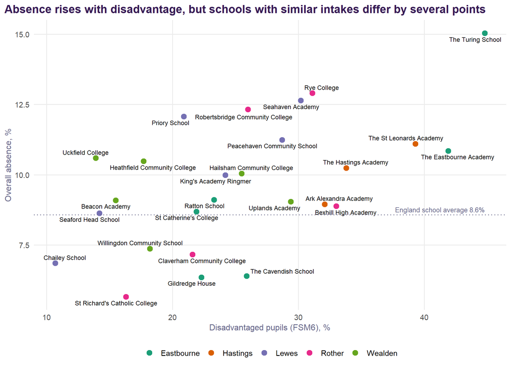

Figure 10: School absence against disadvantage, East Sussex, 2024/25, coloured by district. The dotted line is England’s school average absence.

Disadvantage and absence go together within the county, as they do nationally. But at any level of disadvantage there is a spread of three or four points between schools. Two examples:

- The Cavendish School and Ark Alexandra Academy are both a quarter to a third disadvantaged. They differ by more than two points of absence.
- Priory School in Lewes, one of the county’s less disadvantaged schools, has higher absence than five of the six Eastbourne schools.

That spread is where school practice shows. Section 7.1 separates it from intake more formally.

## 6.5 Suspensions

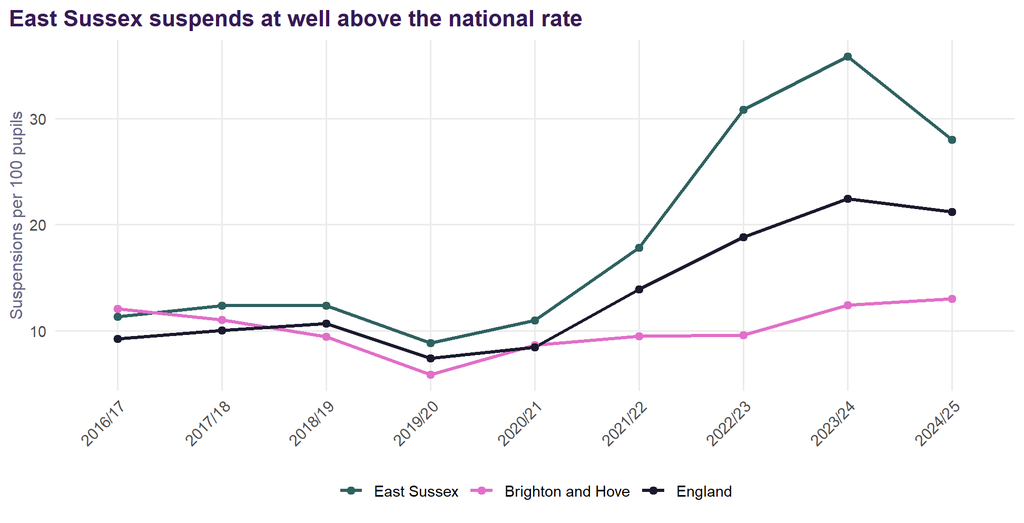

Figure 11: Suspensions per 100 pupils, state-funded secondary schools, full academic years.

Suspensions rose sharply everywhere after the pandemic, and further in East Sussex. The county’s rate peaked at 35.9 per 100 pupils in 2023/24 (23rd highest of 152). In 2024/25 it was 28.0, against 21.2 for England and 13.0 for Brighton and Hove. Permanent exclusion, by contrast, is *below* the national rate: 0.13 per 100 against 0.23.

Table 8: Suspensions and permanent exclusions by school, latest year. A rate is suspensions per 100 pupils on roll; one pupil can be suspended more than once.

| School | Pupils | Suspensions per 100 | Permanent exclusions |
| --- | --- | --- | --- |
| The Hastings Academy | 808 | 89.9 | 8 |
| Ark Alexandra Academy | 1431 | 74.7 | 2 |
| The St Leonards Academy | 1322 | 73.7 | 0 |
| Uplands Academy | 736 | 53.4 | 1 |
| The Eastbourne Academy | 800 | 48.9 | 6 |
| Seahaven Academy | 745 | 47.9 | 4 |
| St Catherine's College | 1072 | 44.1 | 1 |
| The Turing School | 765 | 34.0 | 1 |
| King's Academy Ringmer | 642 | 32.7 | 4 |
| Rye College | 616 | 29.1 | 2 |
| Uckfield College | 1602 | 26.8 | 1 |
| Bexhill High Academy | 1454 | 26.0 | 3 |
| Ratton School | 1197 | 22.9 | 0 |
| Priory School | 1163 | 22.5 | 0 |
| Hailsham Community College | 1615 | 19.4 | 1 |
| Willingdon Community School | 1093 | 17.3 | 0 |
| Claverham Community College | 1148 | 16.7 | 1 |
| Heathfield Community College | 1437 | 14.9 | 2 |
| Beacon Academy | 1662 | 14.5 | 0 |
| Peacehaven Community School | 903 | 13.8 | 1 |
| Chailey School | 855 | 12.2 | 0 |
| St Richard's Catholic College | 1033 | 9.8 | 0 |
| The Cavendish School | 1372 | 7.8 | 0 |
| Gildredge House | 1168 | 6.8 | 0 |
| Seaford Head School | 1448 | 1.5 | 0 |
| Robertsbridge Community College | 733 | 0.0 | 0 |

The rate varies enormously between schools, and that variation is the real policy question about suspensions in the county. For absence they are a small part of the story. Sessions lost to suspension are 0.29% of possible sessions in 2025/26, about 3% of all absence. A county with England’s suspension rate would have almost exactly the absence East Sussex has. Suspension is worth attention for what it does to the pupils suspended, who are disproportionately disadvantaged and have special educational needs. It is not the reason the county’s absence is high.

# 7 What absence costs, school by school

## 7.1 Two signals: what a school adds, and how it manages attendance

The Lever report separates each school’s absence into two parts:

- the part its intake predicts;
- the residual, which is broadly what the school’s own attendance practice adds or removes.

It sets the residual against a value-added measure that does *not* control for absence. That measure gives schools credit for attendance they have improved, and charges them for attendance they have not. Figure 12 places every East Sussex school on those two axes, against the national cloud. These are the two models refitted for this document, both exact copies of the Lever report’s.

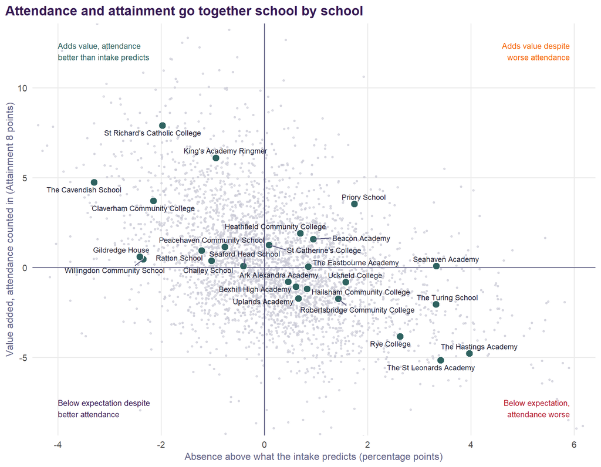

Figure 12: East Sussex schools on the joint-signal plane, mean over 2021/22 to 2024/25. Horizontal: absence above (right) or below (left) what the intake predicts. Vertical: Attainment 8 above or below what the intake predicts, with attendance counted as part of the school’s contribution. Grey: every school in England.

Across the county’s schools the two signals are strongly related (correlation -0.69). Schools that hold attendance better than their intake predicts also tend to add more to results.

- **Better attendance and value added.** Claverham Community College, Willingdon Community School, Chailey School, St Richard’s Catholic College, Seaford Head School, Ratton School, The Cavendish School, Gildredge House, King’s Academy Ringmer, Peacehaven Community School.
- **Value added despite worse attendance.** Heathfield Community College, Priory School, The Eastbourne Academy, Beacon Academy, Seahaven Academy, St Catherine’s College. In these schools attendance is the obvious next lever.
- **Below expectation, with worse attendance.** Robertsbridge Community College, Uckfield College, The St Leonards Academy, The Hastings Academy, Hailsham Community College, Bexhill High Academy, Ark Alexandra Academy, Rye College, The Turing School, Uplands Academy. Here both signals point the same way. The Hastings and St Leonards academies, Rye College and the Turing School are furthest out.
- **Below expectation despite better attendance.** No East Sussex school is in this quadrant. Every school below expectation also has worse attendance than its intake predicts, which makes attendance the common thread.

Two cautions apply.

- **Some of the residual is not the school’s doing.** About half of national absence is explained by intake. The rest includes local health, transport and family circumstances that a school can influence only partly.
- **These are four-year averages.** Several of the schools furthest from the centre have changed leadership or trust since.

## 7.2 What closing the gap would be worth

The Lever report’s scenario asks what each school would gain if its absence fell to the national school average of 8.6%. The model’s absence coefficient converts the fall into Attainment 8 points. The Lever report also works through the alternative lever: bringing each school’s disadvantage down to the county average.

Table 9: Predicted Attainment 8 gain if each school’s absence fell to the national school average (2024/25), and, for comparison, if its disadvantage fell to the county average. Schools already at or below either target gain nothing from it. Indicative only: see the cautions in the Lever report.

| School | District | Absence % | FSM % | Gain, all pupils | Gain, disadvantaged | Gain from FSM to county average |
| --- | --- | --- | --- | --- | --- | --- |
| The Turing School | Eastbourne | 15.0 | 44.8 | +4.3 | +4.0 | +1.0 |
| Priory School | Lewes | 12.1 | 20.9 | +3.4 | +2.7 | +0.0 |
| Seahaven Academy | Lewes | 12.6 | 30.2 | +3.4 | +4.0 | +0.3 |
| Rye College | Rother | 12.9 | 31.1 | +3.2 | +3.4 | +0.4 |
| Robertsbridge Community College | Rother | 12.3 | 26.0 | +3.1 | +3.4 | +0.0 |
| Peacehaven Community School | Lewes | 11.2 | 28.7 | +2.3 | +2.4 | +0.2 |
| Heathfield Community College | Wealden | 10.5 | 17.7 | +2.1 | +2.9 | +0.0 |
| Uckfield College | Wealden | 10.6 | 13.9 | +2.1 | +1.6 | +0.0 |
| The Eastbourne Academy | Eastbourne | 10.8 | 41.9 | +1.9 | +2.4 | +0.9 |
| The St Leonards Academy | Hastings | 11.1 | 39.3 | +1.8 | +2.1 | +0.7 |
| King's Academy Ringmer | Lewes | 10.0 | 24.2 | +1.5 | +1.5 | +0.0 |
| The Hastings Academy | Hastings | 10.2 | 33.8 | +1.4 | +1.5 | +0.5 |
| Hailsham Community College | Wealden | 10.0 | 25.5 | +1.2 | +1.3 | +0.0 |
| Beacon Academy | Wealden | 9.1 | 15.5 | +0.6 | +0.7 | +0.0 |
| Ratton School | Eastbourne | 9.1 | 23.3 | +0.5 | +0.5 | +0.0 |
| Uplands Academy | Wealden | 9.0 | 29.4 | +0.5 | +0.6 | +0.3 |
| Ark Alexandra Academy | Hastings | 8.9 | 32.1 | +0.4 | +0.4 | +0.5 |
| Bexhill High Academy | Rother | 8.9 | 33.0 | +0.3 | +0.3 | +0.5 |
| St Catherine's College | Eastbourne | 8.7 | 21.9 | +0.1 | +0.2 | +0.0 |
| Seaford Head School | Lewes | 8.6 | 14.2 | +0.1 | +0.1 | +0.0 |
| The Cavendish School | Eastbourne | 6.4 | 25.9 | +0.0 | +0.0 | +0.0 |

20 of the county’s 26 schools are above the national average. At the highest-absence schools the predicted gain is three to four Attainment 8 points: The Turing School, Seahaven Academy, Priory School, Rye College and Robertsbridge Community College. Across all 20, the average is 1.7 points for all pupils and 1.8 for disadvantaged pupils, whose results respond more to attendance.

The disadvantage lever buys very little by comparison: at most 1.0 points, at the schools with the highest concentrations. The county’s schools do not have extreme concentrations of disadvantage, and the model gives concentration a small coefficient. In East Sussex, as the Lever report found for Brighton and Hove, attendance is the lever with the mechanical advantage.

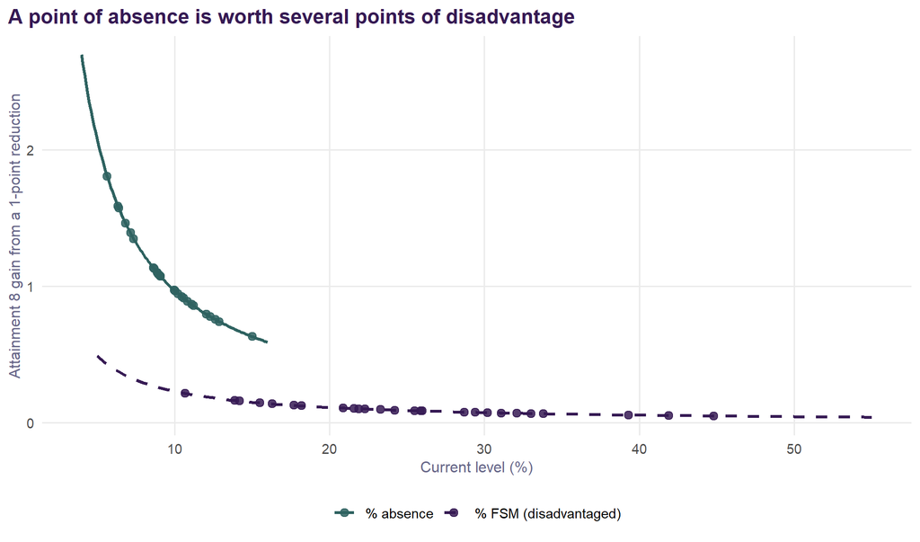

Figure 13: Predicted Attainment 8 gain from a one-point reduction, at each starting level: absence (solid) and disadvantage (dashed). Returns grow as each falls, reading right to left. East Sussex schools marked on each curve.

# 8 School by school: contextual league tables

A raw league table mostly ranks intakes. The contextual tables below rank schools on how far their results sit above or below what the national model expects, given their pupils’ disadvantage, prior attainment, absence and the rest. This is the measure the Lever report uses for Brighton and Hove. The 2025/26 column is provisional, from the first release of that year’s results.

**All pupils**

Value added, all pupils: observed Attainment 8 minus the national model’s expectation, in points. Schools ordered by their mean.

| School | 2021/22 | 2022/23 | 2023/24 | 2024/25 | 2025/26 | Mean | Years |
| --- | --- | --- | --- | --- | --- | --- | --- |
| King's Academy Ringmer | +5.8 | +4.5 | +4.5 | +5.8 | +7.9 | +5.7 | 5 |
| Priory School | +5.8 | +4.6 | +7.4 | +1.6 | +2.5 | +4.4 | 5 |
| St Richard's Catholic College | +5.9 | +4.2 | +1.1 | +4.3 |  | +3.9 | 4 |
| Seahaven Academy | +5.2 | +2.6 | +1.8 | +2.2 | +4.4 | +3.2 | 5 |
| Heathfield Community College | -5.3 | +4.9 | +3.6 | +5.1 | +2.8 | +2.2 | 5 |
| Beacon Academy | +4.7 | +3.1 | +3.2 | +0.5 | -1.5 | +2.0 | 5 |
| Uckfield College | +6.4 | -1.0 | +1.1 | -1.2 | -2.3 | +0.6 | 5 |
| St Catherine's College | +5.2 | -1.9 | +1.1 | +0.2 | -2.0 | +0.5 | 5 |
| The Eastbourne Academy | +0.4 | +0.4 | -4.0 | +2.7 | +2.9 | +0.5 | 5 |
| Seaford Head School | -0.6 | +0.0 | +1.9 | +0.5 | +0.6 | +0.5 | 5 |
| Claverham Community College | -1.5 | +3.7 | -0.2 | +1.5 | -1.3 | +0.4 | 5 |
| Peacehaven Community School | -1.5 | -1.4 | +2.3 | +2.6 | -0.3 | +0.4 | 5 |
| Ratton School | -0.3 | -0.3 | -2.2 | -0.3 | +2.5 | -0.1 | 5 |
| The Cavendish School | +0.6 | -0.4 | +1.7 | -1.3 | -3.0 | -0.5 | 5 |
| Uplands Academy |  |  | +0.3 | -2.2 | -1.5 | -1.1 | 3 |
| Bexhill High Academy | -2.1 | -1.7 | -1.6 | -1.5 | +0.7 | -1.2 | 5 |
| Robertsbridge Community College | -2.5 | -2.6 | +1.6 | -1.7 |  | -1.3 | 4 |
| Chailey School | -2.9 | -2.3 | +3.1 | -3.2 | -1.7 | -1.4 | 5 |
| Ark Alexandra Academy | -2.4 | -3.8 | -1.2 | -0.5 | -0.1 | -1.6 | 5 |
| Gildredge House | -4.1 | -2.4 | -0.3 | -1.5 | +0.2 | -1.6 | 5 |
| Rye College | +2.2 | -1.8 | -3.4 | -3.3 | -2.1 | -1.7 | 5 |
| The Turing School |  |  | -3.4 | +1.6 | -3.7 | -1.9 | 3 |
| Willingdon Community School | -0.3 | -4.0 | -1.6 | -3.5 | -3.2 | -2.5 | 5 |
| Hailsham Community College | -0.4 | -0.7 | -4.6 | -4.4 |  | -2.5 | 4 |
| Mulberry Academy Hastings (formerly The Hastings Academy) | -1.9 | -4.9 | -4.2 | -2.9 | -6.2 | -4.0 | 5 |
| The St Leonards Academy | -6.1 | -3.8 | -6.0 | -5.3 | -5.2 | -5.3 | 5 |

**Disadvantaged pupils**

Value added, disadvantaged pupils. These are smaller groups, and a school’s figure can move by several points from year to year.

| School | 2021/22 | 2022/23 | 2023/24 | 2024/25 | 2025/26 | Mean | Years |
| --- | --- | --- | --- | --- | --- | --- | --- |
| Heathfield Community College | -6.4 | +10.8 | +9.7 | +15.0 | +2.4 | +6.3 | 5 |
| King's Academy Ringmer | +4.5 | +10.6 | +10.2 | +0.6 | +2.9 | +5.8 | 5 |
| Beacon Academy | +8.4 | +0.4 | +10.2 | +3.9 | -2.7 | +4.0 | 5 |
| St Richard's Catholic College | +2.8 | +4.7 | +5.0 | +1.6 |  | +3.5 | 4 |
| Seahaven Academy | +2.7 | +4.7 | +4.0 | +3.2 | +1.9 | +3.3 | 5 |
| St Catherine's College | +9.3 | +0.3 | +3.3 | +2.6 | -1.0 | +2.9 | 5 |
| Uplands Academy |  |  | -0.2 | +2.3 | +4.1 | +2.1 | 3 |
| The Eastbourne Academy | +1.2 | +2.0 | -1.8 | +4.2 | +2.2 | +1.6 | 5 |
| The Cavendish School | +2.2 | +1.8 | +2.5 | +2.8 | -2.2 | +1.4 | 5 |
| Seaford Head School | +1.2 | -3.4 | +4.8 | +2.3 | +1.6 | +1.3 | 5 |
| Claverham Community College | -0.3 | +6.1 | -2.7 | +3.9 | -4.1 | +0.6 | 5 |
| Robertsbridge Community College | -1.5 | +0.2 | +3.5 | -0.7 |  | +0.4 | 4 |
| Uckfield College | +5.4 | -1.1 | +2.8 | -10.0 | +3.0 | +0.0 | 5 |
| Peacehaven Community School | -1.2 | -5.0 | -1.0 | +0.6 | +2.6 | -0.8 | 5 |
| Bexhill High Academy | -1.8 | -3.2 | +0.8 | -1.0 | -0.0 | -1.0 | 5 |
| Ratton School | +2.5 | -2.7 | -2.6 | -3.5 | +0.9 | -1.1 | 5 |
| Ark Alexandra Academy | -1.6 | -3.2 | -3.6 | +1.1 | -0.0 | -1.5 | 5 |
| Hailsham Community College | -3.5 | +0.7 | -2.9 | -1.7 |  | -1.8 | 4 |
| Mulberry Academy Hastings (formerly The Hastings Academy) | +0.2 | -2.0 | -2.6 | -2.7 | -3.0 | -2.0 | 5 |
| Priory School | -1.2 | -0.9 | +0.1 | -6.6 | -1.7 | -2.1 | 5 |
| Rye College | -0.2 | -2.7 | -3.7 | -3.9 | -1.5 | -2.4 | 5 |
| The Turing School |  |  | -2.8 | -3.4 | -3.6 | -3.3 | 3 |
| Willingdon Community School | -5.4 | -1.4 | +4.0 | -8.2 | -7.3 | -3.7 | 5 |
| The St Leonards Academy | -5.8 | -6.0 | -3.7 | -3.9 | -4.6 | -4.8 | 5 |
| Gildredge House | -9.9 | -8.4 | -1.9 | -3.1 | -1.6 | -5.0 | 5 |
| Chailey School | -6.5 | -2.2 | -10.7 | -1.6 | -5.6 | -5.3 | 5 |

**Non-disadvantaged pupils**

Value added, non-disadvantaged pupils.

| School | 2021/22 | 2022/23 | 2023/24 | 2024/25 | 2025/26 | Mean | Years |
| --- | --- | --- | --- | --- | --- | --- | --- |
| Priory School | +7.1 | +5.7 | +8.3 | +3.4 | +2.5 | +5.4 | 5 |
| King's Academy Ringmer | +6.0 | +2.7 | +2.6 | +7.3 | +8.2 | +5.4 | 5 |
| St Richard's Catholic College | +6.2 | +4.2 | +0.6 | +4.8 |  | +3.9 | 4 |
| Seahaven Academy | +6.3 | +1.8 | +0.6 | +1.5 | +5.5 | +3.1 | 5 |
| Heathfield Community College | -5.1 | +3.9 | +2.2 | +2.7 | +2.7 | +1.3 | 5 |
| Beacon Academy | +3.9 | +3.0 | +1.3 | -0.8 | -1.9 | +1.1 | 5 |
| Peacehaven Community School | -1.6 | +0.4 | +3.5 | +3.3 | -1.6 | +0.8 | 5 |
| Claverham Community College | -0.9 | +3.3 | +0.7 | +1.1 | -0.5 | +0.7 | 5 |
| The Eastbourne Academy | -0.0 | +0.8 | -5.0 | +2.3 | +5.3 | +0.7 | 5 |
| The Turing School |  |  | -2.3 | +7.0 | -3.4 | +0.5 | 3 |
| Uckfield College | +5.9 | -0.9 | +0.2 | -0.6 | -3.8 | +0.2 | 5 |
| Seaford Head School | -1.0 | +0.0 | +0.8 | -0.6 | +0.1 | -0.1 | 5 |
| Ratton School | -1.0 | -0.4 | -2.5 | +0.1 | +2.5 | -0.3 | 5 |
| St Catherine's College | +3.8 | -2.8 | +0.1 | -0.8 | -2.0 | -0.4 | 5 |
| Ark Alexandra Academy | -1.6 | -3.9 | +1.8 | -0.7 | +0.7 | -0.7 | 5 |
| The Cavendish School | +0.3 | -0.6 | +1.7 | -2.4 | -2.8 | -0.8 | 5 |
| Gildredge House | -3.0 | -0.0 | +0.1 | -1.3 | +0.2 | -0.8 | 5 |
| Rye College | +3.6 | -1.6 | -2.3 | -2.8 | -1.7 | -1.0 | 5 |
| Bexhill High Academy | -2.1 | -0.4 | -2.6 | -1.2 | +1.1 | -1.1 | 5 |
| Chailey School | -2.5 | -2.7 | +4.4 | -3.6 | -1.4 | -1.2 | 5 |
| Robertsbridge Community College | -2.7 | -4.0 | +0.4 | -2.3 |  | -2.1 | 4 |
| Willingdon Community School | +1.5 | -4.6 | -2.7 | -2.8 | -2.2 | -2.2 | 5 |
| Uplands Academy |  |  | -0.5 | -3.5 | -3.0 | -2.4 | 3 |
| Hailsham Community College | -0.3 | -1.9 | -5.7 | -5.7 |  | -3.4 | 4 |
| Mulberry Academy Hastings (formerly The Hastings Academy) | -1.8 | -4.5 | -3.5 | -2.2 | -5.5 | -3.5 | 5 |
| The St Leonards Academy | -5.4 | -2.6 | -6.2 | -4.9 | -4.5 | -4.7 | 5 |

The county has schools at both ends of the national distribution:

- **At the top on all pupils:** King’s Academy Ringmer, Priory School, St Richard’s Catholic College. These schools consistently get more from their pupils than the model expects.
- **At the bottom:** Hailsham Community College, Mulberry Academy Hastings (formerly The Hastings Academy), The St Leonards Academy. These are consistently below expectation, and are the schools where trust and leadership have since changed.

# 9 East Sussex and Brighton and Hove

The two authorities are neighbours on the same coast, and some pupils cross the boundary between them each day. On the headline measures they look alike: absence well above England’s, near-average disadvantage, and a disadvantage gap of about fifteen points. The model says they are quite different.

Table 10: The two authorities side by side. Absence and suspension figures are the latest DfE releases; model figures are from the national models over 2021/22 to 2024/25.

| Measure | East Sussex | Brighton and Hove |
| --- | --- | --- |
| Attainment 8, all pupils (2024/25) | 43.8 | 45.5 |
| Attainment 8, disadvantaged (2024/25) | 33.0 | 33.9 |
| Disadvantaged % | 25.5 | 28.8 |
| Prior attainment (KS2, centred) | 3.79 | 4.71 |
| Absence, 2025/26 (rank) | 8.9% (31st) | 9.8% (6th) |
| Absence above intake-predicted (rank) | +0.32 (59th) | +1.98 (3rd) |
| Illness, % of possible sessions | 4.29 | 5.42 |
| Suspensions per 100, 2024/25 | 28.0 | 13.0 |
| LA effect, all pupils (rank) | 49th | 5th |
| LA effect, disadvantaged (rank) | 60th | 14th |
| Disadvantaged rank: with / without absence control | 57th / 61st | 15th / 69th |
| Absence's cost to the gap with England (points, all pupils) | -1.11 | -1.96 |

- **Brighton and Hove** has effective schools, an advantaged intake and a local absence problem out of all proportion to its intake. Absence is the one thing standing between the city and the top of the national table. The policy question there is diagnostic: *why* is attendance so much worse than the city’s pupils would predict?
- **East Sussex** has schools that perform about as the model expects, pupils who arrive with lower prior attainment, and absence that is high but roughly what its intake predicts. Absence is still the largest factor the county can act on, but it is not an anomaly. The policy question is about delivery: how to move a typical, intake-driven attendance problem in places where it is concentrated, chiefly the coastal towns and a handful of schools.
- **What they share** is the composition of the problem. In both, most of the excess is pupils recorded as ill, not holidays, lateness or exclusion. In neither does the mix of pupils between schools explain attainment. Both would get more from attendance than from any redistribution of disadvantage.
- **Where they differ most sharply apart from that** is suspension. East Sussex suspends at more than twice Brighton and Hove’s rate. That is not a large part of either authority’s absence, but it is a large difference in practice between two neighbours.

# 10 Implications and questions for discussion

These are offered as starting points for the conversation with the county. They are not recommendations made with knowledge of what the county already does.

1. **Attendance is the largest factor the county can act on.** It accounts for as much of the attainment gap with England as prior attainment does. The gain per point is largest in the highest-absence schools, and largest for disadvantaged pupils.
2. **The county’s absence is the national problem, concentrated.** Approaches that work for pupils with lower prior attainment, in coastal and rural areas with poor transport, are likely to transfer. The improvement since 2022/23 suggests something is already working. It would be worth knowing what, and in which schools.
3. **Illness is most of the excess.** Illness absence above the national rate, here and in Brighton and Hove, is beyond what schools alone can address, and points to joint work with health and children’s services. The published data cannot say what lies behind it; the county’s own attendance records could.
4. **Reduced timetables and suspensions are system decisions.** Both run above national rates. Neither is large in absence terms, but both fall on the pupils least able to absorb lost time, and both are within the system’s control.
5. **Prior attainment is the other half of the gap.** Pupils arriving with lower Key Stage 2 scores account for as much of the county’s shortfall as absence does. The primary phase is part of the secondary story.
6. **Hastings.** The Hastings and St Leonards academies have the lowest value added in the county, with absence well above what their intakes predict, and both have just changed trust. The value-added and attendance measures in this document give a baseline against which the new arrangements could be followed.

**What would sharpen this.** All of the following are published or routinely collected by the county:

- attendance by year group and pupil characteristic for each school;
- persistent and severe absence by reason;
- the use of reduced timetables and alternative provision;
- the primary schools that feed each secondary.

Any of these would allow the school-level picture here to be taken further.

# Notes on method

**The decomposition.** For a model fitted on log Attainment 8, a school-year’s outcome is the sum of its fixed-effect terms (coefficient times predictor), its random effects (year, Ofsted rating, region, local authority) and a residual. Averaging over an authority’s school-years and subtracting England’s average gives the gap in log points as an exact sum of one term per factor. Each term is converted to approximate Attainment 8 points by multiplying by England’s geometric mean Attainment 8. The pieces are computed on the school-years each model was fitted on, so the three groups cover slightly different sets.

**Absence.** Absence rates in Section 6 are sessions-weighted across pupils, from the DfE’s school-level release for autumn and spring terms. They differ slightly from the school-mean rates in the model tables, which weight every school equally.

**Sources.** DfE school performance tables 2021/22–2024/25 and Key stage 4 performance 2025/26 (provisional); Pupil absence in schools in England; Suspensions and permanent exclusions in England; School workforce in England; Get Information about Schools. All are published under the Open Government Licence v3.0. The models and code are at https://github.com/adamdennett/school_attainment_tool; this document is built by `R/17_area_analysis.R` and `east_sussex.qmd`.

## Footnotes

[^1]: These two ranks come from the peer-review re-estimation in the Lever report, fitted on a common sample so that the two specifications can be compared. They differ slightly from the published model’s ranks in the table above for that reason.